[figure not shown]

# USM Numérica

## Libraría Pandas

### Objetivos

1. Conocer los principales comandos de la librería pandas
2. Utilizar pandas para limpieza y manipulación de datos.

## Sobre el autor

### Sebastián Flores

#### ICM UTFSM

#### sebastian.flores@usm.cl

## Sobre la presentación

#### Contenido creada en ipython notebook (jupyter)

#### Versión en Slides gracias a RISE de Damián Avila

Software:

- python 2.7 o python 3.1
- pandas 0.16.1

Opcional:

- numpy 1.9.2
- matplotlib 1.3.1

## Aprender haciendo

Consideraremos el siguiente archivo `data.csv` que contiene datos incompletos:

```python
%%bash
cat data/data.csv
```

```
diametro;altura;volumen;tipo_de_arbol
11.2;75;19.9;Cherrie Tree
11.3;79;24.2;Cherry Tree
11.4;76;21.0;Cherry Tree
11.4;76;21.4;Apple Tree
13.7;71;25.7;Cherry Tree
13.8;64;24.9;Cherry Tree
14.0;78;34.5;Cherrie Tree
14.2;80;31.7;Cherry Tree
;74;36.3;Apple Tree
16.0;72;38.3;Cherry Tree
16.3;77;42.6;Cherry Tree
17.3;81;55.4;Apple Tree
17.5;;55.7;Cherry Tree
17.9;80;58.3;Cherry Tree
18.0;80;51.5;Cherry Tree
18.0;;51.0;
20.6;;;Cherry Tree
```

## 1.- ¿Porqué utilizar pandas?

**Razón oficial**: Porque en numpy no es posible mezclar tipos de datos, lo cual complica cargar, usar, limpiar y guardar datos mixtos.

**Razón personal**: Porque habían cosas que en R eran más fáciles pero no pythonísticas. La librería pandas es un excelente compromiso.

```python
import numpy as np
df = np.loadtxt("data/data.csv", delimiter=";", dtype=str)
print( df )
```

```
[['diametro' 'altura' 'volumen' 'tipo_de_arbol']
 ['11.2' '75' '19.9' 'Cherrie Tree']
 ['11.3' '79' '24.2' 'Cherry Tree']
 ['11.4' '76' '21.0' 'Cherry Tree']
 ['11.4' '76' '21.4' 'Apple Tree']
 ['13.7' '71' '25.7' 'Cherry Tree']
 ['13.8' '64' '24.9' 'Cherry Tree']
 ['14.0' '78' '34.5' 'Cherrie Tree']
 ['14.2' '80' '31.7' 'Cherry Tree']
 ['' '74' '36.3' 'Apple Tree']
 ['16.0' '72' '38.3' 'Cherry Tree']
 ['16.3' '77' '42.6' 'Cherry Tree']
 ['17.3' '81' '55.4' 'Apple Tree']
 ['17.5' '' '55.7' 'Cherry Tree']
 ['17.9' '80' '58.3' 'Cherry Tree']
 ['18.0' '80' '51.5' 'Cherry Tree']
 ['18.0' '' '51.0' '']
 ['20.6' '' '' 'Cherry Tree']]
```

```python
import pandas as pd
df = pd.read_csv("data/data.csv", sep=";")
print( df )
#df
```

```
    diametro  altura  volumen tipo_de_arbol
0       11.2    75.0     19.9  Cherrie Tree
1       11.3    79.0     24.2   Cherry Tree
2       11.4    76.0     21.0   Cherry Tree
3       11.4    76.0     21.4    Apple Tree
4       13.7    71.0     25.7   Cherry Tree
5       13.8    64.0     24.9   Cherry Tree
6       14.0    78.0     34.5  Cherrie Tree
7       14.2    80.0     31.7   Cherry Tree
8        NaN    74.0     36.3    Apple Tree
9       16.0    72.0     38.3   Cherry Tree
10      16.3    77.0     42.6   Cherry Tree
11      17.3    81.0     55.4    Apple Tree
12      17.5     NaN     55.7   Cherry Tree
13      17.9    80.0     58.3   Cherry Tree
14      18.0    80.0     51.5   Cherry Tree
15      18.0     NaN     51.0           NaN
16      20.6     NaN      NaN   Cherry Tree
```

```python
inch2m = 0.0254
feet2m = 0.3048
df.diametro = df.diametro * inch2m
df.altura = df.altura * feet2m
df.volumen = df.volumen * (feet2m**3)
df.tipo_de_arbol = "Cherry Tree"
df
```

|  | diametro | altura | volumen | tipo_de_arbol |
| --- | --- | --- | --- | --- |
| 0 | 0.28448 | 22.8600 | 0.563505 | Cherry Tree |
| 1 | 0.28702 | 24.0792 | 0.685268 | Cherry Tree |
| 2 | 0.28956 | 23.1648 | 0.594654 | Cherry Tree |
| 3 | 0.28956 | 23.1648 | 0.605981 | Cherry Tree |
| 4 | 0.34798 | 21.6408 | 0.727743 | Cherry Tree |
| 5 | 0.35052 | 19.5072 | 0.705089 | Cherry Tree |
| 6 | 0.35560 | 23.7744 | 0.976931 | Cherry Tree |
| 7 | 0.36068 | 24.3840 | 0.897644 | Cherry Tree |
| 8 | NaN | 22.5552 | 1.027902 | Cherry Tree |
| 9 | 0.40640 | 21.9456 | 1.084535 | Cherry Tree |
| 10 | 0.41402 | 23.4696 | 1.206298 | Cherry Tree |
| 11 | 0.43942 | 24.6888 | 1.568753 | Cherry Tree |
| 12 | 0.44450 | NaN | 1.577248 | Cherry Tree |
| 13 | 0.45466 | 24.3840 | 1.650872 | Cherry Tree |
| 14 | 0.45720 | 24.3840 | 1.458318 | Cherry Tree |
| 15 | 0.45720 | NaN | 1.444159 | Cherry Tree |
| 16 | 0.52324 | NaN | NaN | Cherry Tree |

```python
print( df.columns )
```

```
Index(['diametro', 'altura', 'volumen', 'tipo_de_arbol'], dtype='object')
```

```python
print( df.index )
```

```
RangeIndex(start=0, stop=17, step=1)
```

```python
print( df["altura"]*2 )
```

```
0     45.7200
1     48.1584
2     46.3296
3     46.3296
4     43.2816
5     39.0144
6     47.5488
7     48.7680
8     45.1104
9     43.8912
10    46.9392
11    49.3776
12        NaN
13    48.7680
14    48.7680
15        NaN
16        NaN
Name: altura, dtype: float64
```

```python
print( df["diametro"]**2 * df["altura"] / df.volumen )
```

```
0     3.283082
1     2.894717
2     3.266190
3     3.205140
4     3.600840
5     3.399197
6     3.077295
7     3.533824
8          NaN
9     3.342037
10    3.334985
11    3.038820
12         NaN
13    3.053269
14    3.495146
15         NaN
16         NaN
dtype: float64
```

## 2. Lo básico de pandas

- Pandas imita los dataframes de R, pero en python. Todo lo que no tiene sentido es porque se parece demasiado a R.
- Pandas permite tener datos como en tablas de excel: datos en una columna pueden ser mixtos.
- La idea central es que la indexación es "a medida": las columnas y las filas (index) pueden ser enteros o floats, pero también pueden ser strings. Depende de lo que tenga sentido.
- Los elementos básicos de pandas son:
  - **Series**: Conjunto de valores con indexación variable.
  - **DataFrames**: Conjunto de Series.

### 2.1 Series

Una serie es un conveniente conjunto de datos, como una columna de datos de excel, pero con indexación más genérica.

```
pd.Series(self, data=None, index=None, dtype=None, name=None, copy=False, fastpath=False)
```

```python
import pandas as pd
s1 = pd.Series([False, 1, 2., "3", 4 + 0j])
print( s1 )
```

```
0     False
1         1
2       2.0
3         3
4    (4+0j)
dtype: object
```

```python
# Casting a otros tipos
print( list(s1) )
print( set(s1) )
print( np.array(s1) )
```

```
[False, 1, 2.0, '3', (4+0j)]
{False, 1, 2.0, (4+0j), '3'}
[False 1 2.0 '3' (4+0j)]
```

```python
# Ejemplo de operatoria
s0 = pd.Series(range(6), index=range(6))
s1 = pd.Series([1,2,3], index=[1,2,3])
s2 = pd.Series([4,5,6], index=[4,5,6])
s3 = pd.Series([10,10,10], index=[1,4,6])
```

```python
print( s0 )
```

```
0    0
1    1
2    2
3    3
4    4
5    5
dtype: int64
```

```python
print( s0 + s1 )
```

```
0    NaN
1    2.0
2    4.0
3    6.0
4    NaN
5    NaN
dtype: float64
```

```python
print( s0 + s1 + s2 )
```

```
0   NaN
1   NaN
2   NaN
3   NaN
4   NaN
5   NaN
6   NaN
dtype: float64
```

```python
print( s0.add(s1, fill_value=0) )
```

```
0    0.0
1    2.0
2    4.0
3    6.0
4    4.0
5    5.0
dtype: float64
```

### 2.2 DataFrames

Un Dataframe es una colección de Series con una indexación común. Como una planilla de excel.

```
pd.DataFrame(self, data=None, index=None,
             columns=None, dtype=None, copy=False)
```

```python
# dict
df = pd.DataFrame({"col1":[1,2,3,4],
                   "col2":[1., 2., 3., 4.],
                   "col3":["uno", "dos", "tres", "cuatro"]})
df
```

|  | col1 | col2 | col3 |
| --- | --- | --- | --- |
| 0 | 1 | 1.0 | uno |
| 1 | 2 | 2.0 | dos |
| 2 | 3 | 3.0 | tres |
| 3 | 4 | 4.0 | cuatro |

## 3.1 Obteniendo datos

1. **Archivo csv**
2. **Archivo json**
3. **Archivo de excel**: convertir a csv cuidadosamente (elegir un separador apropiado, no comentar strings).

```python
# csv
df = pd.read_csv("data/data.csv", sep=";")
df
```

|  | diametro | altura | volumen | tipo_de_arbol |
| --- | --- | --- | --- | --- |
| 0 | 11.2 | 75.0 | 19.9 | Cherrie Tree |
| 1 | 11.3 | 79.0 | 24.2 | Cherry Tree |
| 2 | 11.4 | 76.0 | 21.0 | Cherry Tree |
| 3 | 11.4 | 76.0 | 21.4 | Apple Tree |
| 4 | 13.7 | 71.0 | 25.7 | Cherry Tree |
| 5 | 13.8 | 64.0 | 24.9 | Cherry Tree |
| 6 | 14.0 | 78.0 | 34.5 | Cherrie Tree |
| 7 | 14.2 | 80.0 | 31.7 | Cherry Tree |
| 8 | NaN | 74.0 | 36.3 | Apple Tree |
| 9 | 16.0 | 72.0 | 38.3 | Cherry Tree |
| 10 | 16.3 | 77.0 | 42.6 | Cherry Tree |
| 11 | 17.3 | 81.0 | 55.4 | Apple Tree |
| 12 | 17.5 | NaN | 55.7 | Cherry Tree |
| 13 | 17.9 | 80.0 | 58.3 | Cherry Tree |
| 14 | 18.0 | 80.0 | 51.5 | Cherry Tree |
| 15 | 18.0 | NaN | 51.0 | NaN |
| 16 | 20.6 | NaN | NaN | Cherry Tree |

```python
df = pd.read_json("data/data.json")
df
```

|  | diametro | altura | volumen | tipo_de_arbol |
| --- | --- | --- | --- | --- |
| 1 | 11.3 | 79.0 | 24.2 | Cherry Tree |
| 2 | 11.4 | 76.0 | 21.0 | Cherry Tree |
| 4 | 13.7 | 71.0 | 25.7 | Cherry Tree |
| 5 | 13.8 | 64.0 | 24.9 | Cherry Tree |
| 7 | 14.2 | 80.0 | 31.7 | Cherry Tree |
| 9 | 16.0 | 72.0 | 38.3 | Cherry Tree |
| 10 | 16.3 | 77.0 | 42.6 | Cherry Tree |
| 12 | 17.5 | NaN | 55.7 | Cherry Tree |
| 13 | 17.9 | 80.0 | 58.3 | Cherry Tree |
| 14 | 18.0 | 80.0 | 51.5 | Cherry Tree |
| 16 | 20.6 | NaN | NaN | Cherry Tree |

## 4.- Inspeccionando datos

1. Accesando las columnas
2. shape
3. head, tail, describe
4. histogram
5. pd.scatter_matrix
6. count_values

```python
df = pd.read_csv("data/data.csv", sep=";")
df.columns
```

```
Index(['diametro', 'altura', 'volumen', 'tipo_de_arbol'], dtype='object')
```

```python
df['altura']
```

```
0     75.0
1     79.0
2     76.0
3     76.0
4     71.0
5     64.0
6     78.0
7     80.0
8     74.0
9     72.0
10    77.0
11    81.0
12     NaN
13    80.0
14    80.0
15     NaN
16     NaN
Name: altura, dtype: float64
```

```python
df.shape
```

```
(17, 4)
```

```python
df.head()
```

|  | diametro | altura | volumen | tipo_de_arbol |
| --- | --- | --- | --- | --- |
| 0 | 11.2 | 75.0 | 19.9 | Cherrie Tree |
| 1 | 11.3 | 79.0 | 24.2 | Cherry Tree |
| 2 | 11.4 | 76.0 | 21.0 | Cherry Tree |
| 3 | 11.4 | 76.0 | 21.4 | Apple Tree |
| 4 | 13.7 | 71.0 | 25.7 | Cherry Tree |

```python
df.tail()
```

|  | diametro | altura | volumen | tipo_de_arbol |
| --- | --- | --- | --- | --- |
| 12 | 17.5 | NaN | 55.7 | Cherry Tree |
| 13 | 17.9 | 80.0 | 58.3 | Cherry Tree |
| 14 | 18.0 | 80.0 | 51.5 | Cherry Tree |
| 15 | 18.0 | NaN | 51.0 | NaN |
| 16 | 20.6 | NaN | NaN | Cherry Tree |

```python
df.describe()
```

|  | diametro | altura | volumen |
| --- | --- | --- | --- |
| count | 16.000000 | 14.000000 | 16.000000 |
| mean | 15.162500 | 75.928571 | 37.025000 |
| std | 2.948418 | 4.615430 | 13.773816 |
| min | 11.200000 | 64.000000 | 19.900000 |
| 25% | 13.125000 | 74.250000 | 24.725000 |
| 50% | 15.100000 | 76.500000 | 35.400000 |
| 75% | 17.600000 | 79.750000 | 51.125000 |
| max | 20.600000 | 81.000000 | 58.300000 |

```python
df.describe(include="all")
```

|  | diametro | altura | volumen | tipo_de_arbol |
| --- | --- | --- | --- | --- |
| count | 16.000000 | 14.000000 | 16.000000 | 16 |
| unique | NaN | NaN | NaN | 3 |
| top | NaN | NaN | NaN | Cherry Tree |
| freq | NaN | NaN | NaN | 11 |
| mean | 15.162500 | 75.928571 | 37.025000 | NaN |
| std | 2.948418 | 4.615430 | 13.773816 | NaN |
| min | 11.200000 | 64.000000 | 19.900000 | NaN |
| 25% | 13.125000 | 74.250000 | 24.725000 | NaN |
| 50% | 15.100000 | 76.500000 | 35.400000 | NaN |
| 75% | 17.600000 | 79.750000 | 51.125000 | NaN |
| max | 20.600000 | 81.000000 | 58.300000 | NaN |

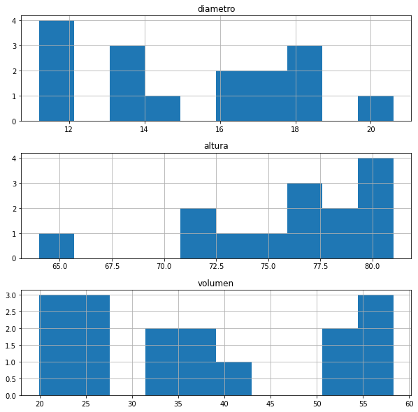

```python
from matplotlib import pyplot as plt
df.hist(figsize=(10,10), layout=(3,1))
#df.hist(figsize=(8,8), layout=(3,1), by="tipo_de_arbol")
plt.show()
```

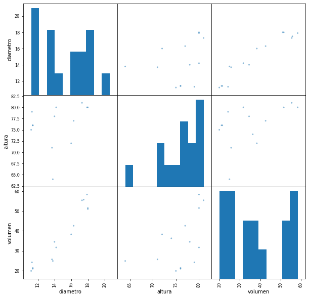

```python
from matplotlib import pyplot as plt
pd.plotting.scatter_matrix(df, figsize=(10,10), range_padding=0.2)
plt.show()
```

```python
df.tipo_de_arbol.value_counts()
```

```
Cherry Tree     11
Apple Tree       3
Cherrie Tree     2
Name: tipo_de_arbol, dtype: int64
```

## 5.- Manipulando DataFrames

1. Agregando columnas
2. Borrando columnas
3. Agregando filas
4. Borrando filas
5. Mask
6. Grouping
7. Imputación de datos
8. Apply
9. Merge (a la SQL)
10. Accesamiento

### 5.1 Agregando columnas

```python
df = pd.read_csv("data/data.csv", sep=";")
df["radio"] = .5 * df.diametro
df
```

|  | diametro | altura | volumen | tipo_de_arbol | radio |
| --- | --- | --- | --- | --- | --- |
| 0 | 11.2 | 75.0 | 19.9 | Cherrie Tree | 5.60 |
| 1 | 11.3 | 79.0 | 24.2 | Cherry Tree | 5.65 |
| 2 | 11.4 | 76.0 | 21.0 | Cherry Tree | 5.70 |
| 3 | 11.4 | 76.0 | 21.4 | Apple Tree | 5.70 |
| 4 | 13.7 | 71.0 | 25.7 | Cherry Tree | 6.85 |
| 5 | 13.8 | 64.0 | 24.9 | Cherry Tree | 6.90 |
| 6 | 14.0 | 78.0 | 34.5 | Cherrie Tree | 7.00 |
| 7 | 14.2 | 80.0 | 31.7 | Cherry Tree | 7.10 |
| 8 | NaN | 74.0 | 36.3 | Apple Tree | NaN |
| 9 | 16.0 | 72.0 | 38.3 | Cherry Tree | 8.00 |
| 10 | 16.3 | 77.0 | 42.6 | Cherry Tree | 8.15 |
| 11 | 17.3 | 81.0 | 55.4 | Apple Tree | 8.65 |
| 12 | 17.5 | NaN | 55.7 | Cherry Tree | 8.75 |
| 13 | 17.9 | 80.0 | 58.3 | Cherry Tree | 8.95 |
| 14 | 18.0 | 80.0 | 51.5 | Cherry Tree | 9.00 |
| 15 | 18.0 | NaN | 51.0 | NaN | 9.00 |
| 16 | 20.6 | NaN | NaN | Cherry Tree | 10.30 |

```python
df.area = np.pi * df.radio **2
df.columns
```

```
Index(['diametro', 'altura', 'volumen', 'tipo_de_arbol', 'radio'], dtype='object')
```

### 5.2 Renombrando columnas

```python
df = pd.read_csv("data/data.csv", sep=";")
print( df.columns )
df.columns = ["RaDiO","AlTuRa","VoLuMeN","TiPo_De_ArBoL"]
```

```
Index(['diametro', 'altura', 'volumen', 'tipo_de_arbol'], dtype='object')
```

```python
print( df.columns )
```

```
Index(['RaDiO', 'AlTuRa', 'VoLuMeN', 'TiPo_De_ArBoL'], dtype='object')
```

```python
df.columns = [col.lower() for col in df.columns]
print( df.columns )
```

```
Index(['radio', 'altura', 'volumen', 'tipo_de_arbol'], dtype='object')
```

### 5.3 Borrando columnas

```python
df = pd.read_csv("data/data.csv", sep=";")
print( df.columns )
```

```
Index(['diametro', 'altura', 'volumen', 'tipo_de_arbol'], dtype='object')
```

```python
df = df[["tipo_de_arbol","volumen", "diametro"]]
df
```

|  | tipo_de_arbol | volumen | diametro |
| --- | --- | --- | --- |
| 0 | Cherrie Tree | 19.9 | 11.2 |
| 1 | Cherry Tree | 24.2 | 11.3 |
| 2 | Cherry Tree | 21.0 | 11.4 |
| 3 | Apple Tree | 21.4 | 11.4 |
| 4 | Cherry Tree | 25.7 | 13.7 |
| 5 | Cherry Tree | 24.9 | 13.8 |
| 6 | Cherrie Tree | 34.5 | 14.0 |
| 7 | Cherry Tree | 31.7 | 14.2 |
| 8 | Apple Tree | 36.3 | NaN |
| 9 | Cherry Tree | 38.3 | 16.0 |
| 10 | Cherry Tree | 42.6 | 16.3 |
| 11 | Apple Tree | 55.4 | 17.3 |
| 12 | Cherry Tree | 55.7 | 17.5 |
| 13 | Cherry Tree | 58.3 | 17.9 |
| 14 | Cherry Tree | 51.5 | 18.0 |
| 15 | NaN | 51.0 | 18.0 |
| 16 | Cherry Tree | NaN | 20.6 |

```python
df = df.drop("tipo_de_arbol", axis=1)
df
```

|  | volumen | diametro |
| --- | --- | --- |
| 0 | 19.9 | 11.2 |
| 1 | 24.2 | 11.3 |
| 2 | 21.0 | 11.4 |
| 3 | 21.4 | 11.4 |
| 4 | 25.7 | 13.7 |
| 5 | 24.9 | 13.8 |
| 6 | 34.5 | 14.0 |
| 7 | 31.7 | 14.2 |
| 8 | 36.3 | NaN |
| 9 | 38.3 | 16.0 |
| 10 | 42.6 | 16.3 |
| 11 | 55.4 | 17.3 |
| 12 | 55.7 | 17.5 |
| 13 | 58.3 | 17.9 |
| 14 | 51.5 | 18.0 |
| 15 | 51.0 | 18.0 |
| 16 | NaN | 20.6 |

```python
df.drop("diametro", axis=1, inplace=True)
df
```

|  | volumen |
| --- | --- |
| 0 | 19.9 |
| 1 | 24.2 |
| 2 | 21.0 |
| 3 | 21.4 |
| 4 | 25.7 |
| 5 | 24.9 |
| 6 | 34.5 |
| 7 | 31.7 |
| 8 | 36.3 |
| 9 | 38.3 |
| 10 | 42.6 |
| 11 | 55.4 |
| 12 | 55.7 |
| 13 | 58.3 |
| 14 | 51.5 |
| 15 | 51.0 |
| 16 | NaN |

### 5.4 Agregando filas (indices)

```python
df = pd.read_csv("data/data.csv", sep=";")
print( df.index )
df
```

```
RangeIndex(start=0, stop=17, step=1)
```

|  | diametro | altura | volumen | tipo_de_arbol |
| --- | --- | --- | --- | --- |
| 0 | 11.2 | 75.0 | 19.9 | Cherrie Tree |
| 1 | 11.3 | 79.0 | 24.2 | Cherry Tree |
| 2 | 11.4 | 76.0 | 21.0 | Cherry Tree |
| 3 | 11.4 | 76.0 | 21.4 | Apple Tree |
| 4 | 13.7 | 71.0 | 25.7 | Cherry Tree |
| 5 | 13.8 | 64.0 | 24.9 | Cherry Tree |
| 6 | 14.0 | 78.0 | 34.5 | Cherrie Tree |
| 7 | 14.2 | 80.0 | 31.7 | Cherry Tree |
| 8 | NaN | 74.0 | 36.3 | Apple Tree |
| 9 | 16.0 | 72.0 | 38.3 | Cherry Tree |
| 10 | 16.3 | 77.0 | 42.6 | Cherry Tree |
| 11 | 17.3 | 81.0 | 55.4 | Apple Tree |
| 12 | 17.5 | NaN | 55.7 | Cherry Tree |
| 13 | 17.9 | 80.0 | 58.3 | Cherry Tree |
| 14 | 18.0 | 80.0 | 51.5 | Cherry Tree |
| 15 | 18.0 | NaN | 51.0 | NaN |
| 16 | 20.6 | NaN | NaN | Cherry Tree |

```python
df = df.reindex( range(20) )
df
```

|  | diametro | altura | volumen | tipo_de_arbol |
| --- | --- | --- | --- | --- |
| 0 | 11.2 | 75.0 | 19.9 | Cherrie Tree |
| 1 | 11.3 | 79.0 | 24.2 | Cherry Tree |
| 2 | 11.4 | 76.0 | 21.0 | Cherry Tree |
| 3 | 11.4 | 76.0 | 21.4 | Apple Tree |
| 4 | 13.7 | 71.0 | 25.7 | Cherry Tree |
| 5 | 13.8 | 64.0 | 24.9 | Cherry Tree |
| 6 | 14.0 | 78.0 | 34.5 | Cherrie Tree |
| 7 | 14.2 | 80.0 | 31.7 | Cherry Tree |
| 8 | NaN | 74.0 | 36.3 | Apple Tree |
| 9 | 16.0 | 72.0 | 38.3 | Cherry Tree |
| 10 | 16.3 | 77.0 | 42.6 | Cherry Tree |
| 11 | 17.3 | 81.0 | 55.4 | Apple Tree |
| 12 | 17.5 | NaN | 55.7 | Cherry Tree |
| 13 | 17.9 | 80.0 | 58.3 | Cherry Tree |
| 14 | 18.0 | 80.0 | 51.5 | Cherry Tree |
| 15 | 18.0 | NaN | 51.0 | NaN |
| 16 | 20.6 | NaN | NaN | Cherry Tree |
| 17 | NaN | NaN | NaN | NaN |
| 18 | NaN | NaN | NaN | NaN |
| 19 | NaN | NaN | NaN | NaN |

```python
# Usando loc para acceder con notación de indices tradicional
df.loc[20, :] = [10, 20, 30, "CT"]
df
```

|  | diametro | altura | volumen | tipo_de_arbol |
| --- | --- | --- | --- | --- |
| 0 | 11.2 | 75.0 | 19.9 | Cherrie Tree |
| 1 | 11.3 | 79.0 | 24.2 | Cherry Tree |
| 2 | 11.4 | 76.0 | 21.0 | Cherry Tree |
| 3 | 11.4 | 76.0 | 21.4 | Apple Tree |
| 4 | 13.7 | 71.0 | 25.7 | Cherry Tree |
| 5 | 13.8 | 64.0 | 24.9 | Cherry Tree |
| 6 | 14.0 | 78.0 | 34.5 | Cherrie Tree |
| 7 | 14.2 | 80.0 | 31.7 | Cherry Tree |
| 8 | NaN | 74.0 | 36.3 | Apple Tree |
| 9 | 16.0 | 72.0 | 38.3 | Cherry Tree |
| 10 | 16.3 | 77.0 | 42.6 | Cherry Tree |
| 11 | 17.3 | 81.0 | 55.4 | Apple Tree |
| 12 | 17.5 | NaN | 55.7 | Cherry Tree |
| 13 | 17.9 | 80.0 | 58.3 | Cherry Tree |
| 14 | 18.0 | 80.0 | 51.5 | Cherry Tree |
| 15 | 18.0 | NaN | 51.0 | NaN |
| 16 | 20.6 | NaN | NaN | Cherry Tree |
| 17 | NaN | NaN | NaN | NaN |
| 18 | NaN | NaN | NaN | NaN |
| 19 | NaN | NaN | NaN | NaN |
| 20 | 10.0 | 20.0 | 30.0 | CT |

### 5.5 Renombrando filas (índices)

```python
df = pd.read_csv("data/data.csv", sep=";")
print(df.index)
```

```
RangeIndex(start=0, stop=17, step=1)
```

```python
df.index = df.index + 10
print(df.index)
```

```
RangeIndex(start=10, stop=27, step=1)
```

```python
df.index = ["i_%d"%idx for idx in df.index]
print(df.index)
```

```
Index(['i_10', 'i_11', 'i_12', 'i_13', 'i_14', 'i_15', 'i_16', 'i_17', 'i_18',
       'i_19', 'i_20', 'i_21', 'i_22', 'i_23', 'i_24', 'i_25', 'i_26'],
      dtype='object')
```

### 5.6 Borrando indices

```python
print(df.index)
print(df)
```

```
Index(['i_10', 'i_11', 'i_12', 'i_13', 'i_14', 'i_15', 'i_16', 'i_17', 'i_18',
       'i_19', 'i_20', 'i_21', 'i_22', 'i_23', 'i_24', 'i_25', 'i_26'],
      dtype='object')
      diametro  altura  volumen tipo_de_arbol
i_10      11.2    75.0     19.9  Cherrie Tree
i_11      11.3    79.0     24.2   Cherry Tree
i_12      11.4    76.0     21.0   Cherry Tree
i_13      11.4    76.0     21.4    Apple Tree
i_14      13.7    71.0     25.7   Cherry Tree
i_15      13.8    64.0     24.9   Cherry Tree
i_16      14.0    78.0     34.5  Cherrie Tree
i_17      14.2    80.0     31.7   Cherry Tree
i_18       NaN    74.0     36.3    Apple Tree
i_19      16.0    72.0     38.3   Cherry Tree
i_20      16.3    77.0     42.6   Cherry Tree
i_21      17.3    81.0     55.4    Apple Tree
i_22      17.5     NaN     55.7   Cherry Tree
i_23      17.9    80.0     58.3   Cherry Tree
i_24      18.0    80.0     51.5   Cherry Tree
i_25      18.0     NaN     51.0           NaN
i_26      20.6     NaN      NaN   Cherry Tree
```

```python
df = df.drop(["i_11","i_13","i_19"], axis=0)
print(df.index)
df
```

```
Index(['i_10', 'i_12', 'i_14', 'i_15', 'i_16', 'i_17', 'i_18', 'i_20', 'i_21',
       'i_22', 'i_23', 'i_24', 'i_25', 'i_26'],
      dtype='object')
```

|  | diametro | altura | volumen | tipo_de_arbol |
| --- | --- | --- | --- | --- |
| i_10 | 11.2 | 75.0 | 19.9 | Cherrie Tree |
| i_12 | 11.4 | 76.0 | 21.0 | Cherry Tree |
| i_14 | 13.7 | 71.0 | 25.7 | Cherry Tree |
| i_15 | 13.8 | 64.0 | 24.9 | Cherry Tree |
| i_16 | 14.0 | 78.0 | 34.5 | Cherrie Tree |
| i_17 | 14.2 | 80.0 | 31.7 | Cherry Tree |
| i_18 | NaN | 74.0 | 36.3 | Apple Tree |
| i_20 | 16.3 | 77.0 | 42.6 | Cherry Tree |
| i_21 | 17.3 | 81.0 | 55.4 | Apple Tree |
| i_22 | 17.5 | NaN | 55.7 | Cherry Tree |
| i_23 | 17.9 | 80.0 | 58.3 | Cherry Tree |
| i_24 | 18.0 | 80.0 | 51.5 | Cherry Tree |
| i_25 | 18.0 | NaN | 51.0 | NaN |
| i_26 | 20.6 | NaN | NaN | Cherry Tree |

```python
df.drop(["i_24","i_25","i_26"], axis=0, inplace=True)
df
```

|  | diametro | altura | volumen | tipo_de_arbol |
| --- | --- | --- | --- | --- |
| i_10 | 11.2 | 75.0 | 19.9 | Cherrie Tree |
| i_12 | 11.4 | 76.0 | 21.0 | Cherry Tree |
| i_14 | 13.7 | 71.0 | 25.7 | Cherry Tree |
| i_15 | 13.8 | 64.0 | 24.9 | Cherry Tree |
| i_16 | 14.0 | 78.0 | 34.5 | Cherrie Tree |
| i_17 | 14.2 | 80.0 | 31.7 | Cherry Tree |
| i_18 | NaN | 74.0 | 36.3 | Apple Tree |
| i_20 | 16.3 | 77.0 | 42.6 | Cherry Tree |
| i_21 | 17.3 | 81.0 | 55.4 | Apple Tree |
| i_22 | 17.5 | NaN | 55.7 | Cherry Tree |
| i_23 | 17.9 | 80.0 | 58.3 | Cherry Tree |

```python
df = df[-5:]
df
```

|  | diametro | altura | volumen | tipo_de_arbol |
| --- | --- | --- | --- | --- |
| i_18 | NaN | 74.0 | 36.3 | Apple Tree |
| i_20 | 16.3 | 77.0 | 42.6 | Cherry Tree |
| i_21 | 17.3 | 81.0 | 55.4 | Apple Tree |
| i_22 | 17.5 | NaN | 55.7 | Cherry Tree |
| i_23 | 17.9 | 80.0 | 58.3 | Cherry Tree |

**Observación**

```
# seleccionar la columna col
# regresa una serie
df[col]

# seleccionar las columnas col1, col2, ..., coln
# regresa dataframe
df[[col1,col2,.., coln]]

# selecciona solo el indice inicio
# regresa un dataframe
df[inicio:(inicio+1)]

# selecciona los indices en notacion
#regresa un dataframe
df[inicio:fin:salto]

# seleccion mixta
# regresa un dataframe
df.loc[inicio:fin:salto, col1:col2]
```

### 5.7 Masking

```python
df = pd.read_csv("data/data.csv", sep=";")
vol_mean = df.volumen.mean()
vol_std = df.volumen.std()
```

```python
mask_1 = df.altura < 80
mask_2 =  df.volumen <= vol_mean + vol_std
df1 = df[ mask_1 & mask_2 ]
df1
```

|  | diametro | altura | volumen | tipo_de_arbol |
| --- | --- | --- | --- | --- |
| 0 | 11.2 | 75.0 | 19.9 | Cherrie Tree |
| 1 | 11.3 | 79.0 | 24.2 | Cherry Tree |
| 2 | 11.4 | 76.0 | 21.0 | Cherry Tree |
| 3 | 11.4 | 76.0 | 21.4 | Apple Tree |
| 4 | 13.7 | 71.0 | 25.7 | Cherry Tree |
| 5 | 13.8 | 64.0 | 24.9 | Cherry Tree |
| 6 | 14.0 | 78.0 | 34.5 | Cherrie Tree |
| 8 | NaN | 74.0 | 36.3 | Apple Tree |
| 9 | 16.0 | 72.0 | 38.3 | Cherry Tree |
| 10 | 16.3 | 77.0 | 42.6 | Cherry Tree |

```python
# Si se hace dinamicamente, utilizar suficientes parentesis
#df2 = df[ ((vol_mean - vol_std) <= df.volumen) & (df.volumen <= (vol_mean + vol_std) ) ]
df2 = df[ (df.volumen >=(vol_mean - vol_std)) & (df.volumen <= (vol_mean + vol_std) ) ]
df2
```

|  | diametro | altura | volumen | tipo_de_arbol |
| --- | --- | --- | --- | --- |
| 1 | 11.3 | 79.0 | 24.2 | Cherry Tree |
| 4 | 13.7 | 71.0 | 25.7 | Cherry Tree |
| 5 | 13.8 | 64.0 | 24.9 | Cherry Tree |
| 6 | 14.0 | 78.0 | 34.5 | Cherrie Tree |
| 7 | 14.2 | 80.0 | 31.7 | Cherry Tree |
| 8 | NaN | 74.0 | 36.3 | Apple Tree |
| 9 | 16.0 | 72.0 | 38.3 | Cherry Tree |
| 10 | 16.3 | 77.0 | 42.6 | Cherry Tree |

```python
# A veces para simplificar numpy ayuda
mask_1 = df.volumen >= (vol_mean - vol_std)
mask_2 = df.volumen <= (vol_mean + vol_std)
mask = np.logical_and(mask_1, mask_2)
df3 = df[np.logical_not(mask)]
df3
```

|  | diametro | altura | volumen | tipo_de_arbol |
| --- | --- | --- | --- | --- |
| 0 | 11.2 | 75.0 | 19.9 | Cherrie Tree |
| 2 | 11.4 | 76.0 | 21.0 | Cherry Tree |
| 3 | 11.4 | 76.0 | 21.4 | Apple Tree |
| 11 | 17.3 | 81.0 | 55.4 | Apple Tree |
| 12 | 17.5 | NaN | 55.7 | Cherry Tree |
| 13 | 17.9 | 80.0 | 58.3 | Cherry Tree |
| 14 | 18.0 | 80.0 | 51.5 | Cherry Tree |
| 15 | 18.0 | NaN | 51.0 | NaN |
| 16 | 20.6 | NaN | NaN | Cherry Tree |

### 5.8.- Grouping

```python
df = pd.read_csv("data/data.csv", sep=";")
df.columns
```

```
Index(['diametro', 'altura', 'volumen', 'tipo_de_arbol'], dtype='object')
```

```python
g = df.groupby("tipo_de_arbol")
print( g )
```

```
<pandas.core.groupby.generic.DataFrameGroupBy object at 0x125c3a5e0>
```

```python
print( g.count() )
```

```
               diametro  altura  volumen
tipo_de_arbol
Apple Tree            2       3        3
Cherrie Tree          2       2        2
Cherry Tree          11       9       10
```

```python
print( g.sum() ) # .mean(), .std()
```

```
               diametro  altura  volumen
tipo_de_arbol
Apple Tree         28.7   231.0    113.1
Cherrie Tree       25.2   153.0     54.4
Cherry Tree       170.7   679.0    373.9
```

```python
# Ejemplo real
df[["tipo_de_arbol","diametro", "altura"]].groupby("tipo_de_arbol").mean()
```

| tipo_de_arbol | diametro | altura |
| --- | --- | --- |
| Apple Tree | 14.350000 | 77.000000 |
| Cherrie Tree | 12.600000 | 76.500000 |
| Cherry Tree | 15.518182 | 75.444444 |

### 5.9.- Imputación de datos

```python
# Antes de imputar datos, siempre explorar
df.describe(include="all")
```

|  | diametro | altura | volumen | tipo_de_arbol |
| --- | --- | --- | --- | --- |
| count | 16.000000 | 14.000000 | 16.000000 | 16 |
| unique | NaN | NaN | NaN | 3 |
| top | NaN | NaN | NaN | Cherry Tree |
| freq | NaN | NaN | NaN | 11 |
| mean | 15.162500 | 75.928571 | 37.025000 | NaN |
| std | 2.948418 | 4.615430 | 13.773816 | NaN |
| min | 11.200000 | 64.000000 | 19.900000 | NaN |
| 25% | 13.125000 | 74.250000 | 24.725000 | NaN |
| 50% | 15.100000 | 76.500000 | 35.400000 | NaN |
| 75% | 17.600000 | 79.750000 | 51.125000 | NaN |
| max | 20.600000 | 81.000000 | 58.300000 | NaN |

```python
# Imputación manual de datos (incorrecto)
df["tipo_de_arbol"][df.tipo_de_arbol=="Cherrie Tree"] = "Cherry Tree"
df
```

|  | diametro | altura | volumen | tipo_de_arbol |
| --- | --- | --- | --- | --- |
| 0 | 11.2 | 75.0 | 19.9 | Cherry Tree |
| 1 | 11.3 | 79.0 | 24.2 | Cherry Tree |
| 2 | 11.4 | 76.0 | 21.0 | Cherry Tree |
| 3 | 11.4 | 76.0 | 21.4 | Apple Tree |
| 4 | 13.7 | 71.0 | 25.7 | Cherry Tree |
| 5 | 13.8 | 64.0 | 24.9 | Cherry Tree |
| 6 | 14.0 | 78.0 | 34.5 | Cherry Tree |
| 7 | 14.2 | 80.0 | 31.7 | Cherry Tree |
| 8 | NaN | 74.0 | 36.3 | Apple Tree |
| 9 | 16.0 | 72.0 | 38.3 | Cherry Tree |
| 10 | 16.3 | 77.0 | 42.6 | Cherry Tree |
| 11 | 17.3 | 81.0 | 55.4 | Apple Tree |
| 12 | 17.5 | NaN | 55.7 | Cherry Tree |
| 13 | 17.9 | 80.0 | 58.3 | Cherry Tree |
| 14 | 18.0 | 80.0 | 51.5 | Cherry Tree |
| 15 | 18.0 | NaN | 51.0 | NaN |
| 16 | 20.6 | NaN | NaN | Cherry Tree |

```python
# Imputación manual de datos
df = pd.read_csv("data/data.csv", sep=";")
index_mask = (df.tipo_de_arbol=="Cherrie Tree")
df.loc[index_mask, "tipo_de_arbol"] = "Cherry Tree" # .loc es esencial
df
```

|  | diametro | altura | volumen | tipo_de_arbol |
| --- | --- | --- | --- | --- |
| 0 | 11.2 | 75.0 | 19.9 | Cherry Tree |
| 1 | 11.3 | 79.0 | 24.2 | Cherry Tree |
| 2 | 11.4 | 76.0 | 21.0 | Cherry Tree |
| 3 | 11.4 | 76.0 | 21.4 | Apple Tree |
| 4 | 13.7 | 71.0 | 25.7 | Cherry Tree |
| 5 | 13.8 | 64.0 | 24.9 | Cherry Tree |
| 6 | 14.0 | 78.0 | 34.5 | Cherry Tree |
| 7 | 14.2 | 80.0 | 31.7 | Cherry Tree |
| 8 | NaN | 74.0 | 36.3 | Apple Tree |
| 9 | 16.0 | 72.0 | 38.3 | Cherry Tree |
| 10 | 16.3 | 77.0 | 42.6 | Cherry Tree |
| 11 | 17.3 | 81.0 | 55.4 | Apple Tree |
| 12 | 17.5 | NaN | 55.7 | Cherry Tree |
| 13 | 17.9 | 80.0 | 58.3 | Cherry Tree |
| 14 | 18.0 | 80.0 | 51.5 | Cherry Tree |
| 15 | 18.0 | NaN | 51.0 | NaN |
| 16 | 20.6 | NaN | NaN | Cherry Tree |

```python
# Imputación de datos: llenar NaNs con promedio
df = pd.read_csv("data/data.csv", sep=";")
df1 = df.fillna(df.mean())
df1
```

|  | diametro | altura | volumen | tipo_de_arbol |
| --- | --- | --- | --- | --- |
| 0 | 11.2000 | 75.000000 | 19.900 | Cherrie Tree |
| 1 | 11.3000 | 79.000000 | 24.200 | Cherry Tree |
| 2 | 11.4000 | 76.000000 | 21.000 | Cherry Tree |
| 3 | 11.4000 | 76.000000 | 21.400 | Apple Tree |
| 4 | 13.7000 | 71.000000 | 25.700 | Cherry Tree |
| 5 | 13.8000 | 64.000000 | 24.900 | Cherry Tree |
| 6 | 14.0000 | 78.000000 | 34.500 | Cherrie Tree |
| 7 | 14.2000 | 80.000000 | 31.700 | Cherry Tree |
| 8 | 15.1625 | 74.000000 | 36.300 | Apple Tree |
| 9 | 16.0000 | 72.000000 | 38.300 | Cherry Tree |
| 10 | 16.3000 | 77.000000 | 42.600 | Cherry Tree |
| 11 | 17.3000 | 81.000000 | 55.400 | Apple Tree |
| 12 | 17.5000 | 75.928571 | 55.700 | Cherry Tree |
| 13 | 17.9000 | 80.000000 | 58.300 | Cherry Tree |
| 14 | 18.0000 | 80.000000 | 51.500 | Cherry Tree |
| 15 | 18.0000 | 75.928571 | 51.000 | NaN |
| 16 | 20.6000 | 75.928571 | 37.025 | Cherry Tree |

```python
# Imputación de datos: llenar NaNs con valor
df2 = df.fillna(0)
df2
```

|  | diametro | altura | volumen | tipo_de_arbol |
| --- | --- | --- | --- | --- |
| 0 | 11.2 | 75.0 | 19.9 | Cherrie Tree |
| 1 | 11.3 | 79.0 | 24.2 | Cherry Tree |
| 2 | 11.4 | 76.0 | 21.0 | Cherry Tree |
| 3 | 11.4 | 76.0 | 21.4 | Apple Tree |
| 4 | 13.7 | 71.0 | 25.7 | Cherry Tree |
| 5 | 13.8 | 64.0 | 24.9 | Cherry Tree |
| 6 | 14.0 | 78.0 | 34.5 | Cherrie Tree |
| 7 | 14.2 | 80.0 | 31.7 | Cherry Tree |
| 8 | 0.0 | 74.0 | 36.3 | Apple Tree |
| 9 | 16.0 | 72.0 | 38.3 | Cherry Tree |
| 10 | 16.3 | 77.0 | 42.6 | Cherry Tree |
| 11 | 17.3 | 81.0 | 55.4 | Apple Tree |
| 12 | 17.5 | 0.0 | 55.7 | Cherry Tree |
| 13 | 17.9 | 80.0 | 58.3 | Cherry Tree |
| 14 | 18.0 | 80.0 | 51.5 | Cherry Tree |
| 15 | 18.0 | 0.0 | 51.0 | 0 |
| 16 | 20.6 | 0.0 | 0.0 | Cherry Tree |

```python
# Imputación de datos: desechar filas con NaN
df3 = df.dropna()
df3
```

|  | diametro | altura | volumen | tipo_de_arbol |
| --- | --- | --- | --- | --- |
| 0 | 11.2 | 75.0 | 19.9 | Cherrie Tree |
| 1 | 11.3 | 79.0 | 24.2 | Cherry Tree |
| 2 | 11.4 | 76.0 | 21.0 | Cherry Tree |
| 3 | 11.4 | 76.0 | 21.4 | Apple Tree |
| 4 | 13.7 | 71.0 | 25.7 | Cherry Tree |
| 5 | 13.8 | 64.0 | 24.9 | Cherry Tree |
| 6 | 14.0 | 78.0 | 34.5 | Cherrie Tree |
| 7 | 14.2 | 80.0 | 31.7 | Cherry Tree |
| 9 | 16.0 | 72.0 | 38.3 | Cherry Tree |
| 10 | 16.3 | 77.0 | 42.6 | Cherry Tree |
| 11 | 17.3 | 81.0 | 55.4 | Apple Tree |
| 13 | 17.9 | 80.0 | 58.3 | Cherry Tree |
| 14 | 18.0 | 80.0 | 51.5 | Cherry Tree |

### 5.10 Apply

```python
df = pd.read_csv("data/data.csv", sep=";")
df1 = df.diametro.apply(lambda x: x*2)
df1
```

```
0     22.4
1     22.6
2     22.8
3     22.8
4     27.4
5     27.6
6     28.0
7     28.4
8      NaN
9     32.0
10    32.6
11    34.6
12    35.0
13    35.8
14    36.0
15    36.0
16    41.2
Name: diametro, dtype: float64
```

```python
# Aplicación incorrecta
df2 = df["tipo_de_arbol"].apply(str.upper) # Error
df2
```

```
---------------------------------------------------------------------------
TypeError                                 Traceback (most recent call last)
<ipython-input-195-1f598baa0fd5> in <module>
      1 # Aplicación incorrecta
----> 2 df2 = df["tipo_de_arbol"].apply(str.upper) # Error
      3 df2

/miniconda3/envs/meetup/lib/python3.9/site-packages/pandas/core/series.py in apply(self, func, convert_dtype, args, **kwds)
   4136             else:
   4137                 values = self.astype(object)._values
-> 4138                 mapped = lib.map_infer(values, f, convert=convert_dtype)
   4139
   4140         if len(mapped) and isinstance(mapped[0], Series):

pandas/_libs/lib.pyx in pandas._libs.lib.map_infer()

TypeError: descriptor 'upper' for 'str' objects doesn't apply to a 'float' object
```

```python
# Aplicación correcta
df2 = df["tipo_de_arbol"].apply(lambda s: str(s).upper() )
df2
```

```
0     CHERRIE TREE
1      CHERRY TREE
2      CHERRY TREE
3       APPLE TREE
4      CHERRY TREE
5      CHERRY TREE
6     CHERRIE TREE
7      CHERRY TREE
8       APPLE TREE
9      CHERRY TREE
10     CHERRY TREE
11      APPLE TREE
12     CHERRY TREE
13     CHERRY TREE
14     CHERRY TREE
15             NAN
16     CHERRY TREE
Name: tipo_de_arbol, dtype: object
```

```python
# Error (o no?)
df3 = df.apply(lambda x: x*2)
df3
```

|  | diametro | altura | volumen | tipo_de_arbol |
| --- | --- | --- | --- | --- |
| 0 | 22.4 | 150.0 | 39.8 | Cherrie TreeCherrie Tree |
| 1 | 22.6 | 158.0 | 48.4 | Cherry TreeCherry Tree |
| 2 | 22.8 | 152.0 | 42.0 | Cherry TreeCherry Tree |
| 3 | 22.8 | 152.0 | 42.8 | Apple TreeApple Tree |
| 4 | 27.4 | 142.0 | 51.4 | Cherry TreeCherry Tree |
| 5 | 27.6 | 128.0 | 49.8 | Cherry TreeCherry Tree |
| 6 | 28.0 | 156.0 | 69.0 | Cherrie TreeCherrie Tree |
| 7 | 28.4 | 160.0 | 63.4 | Cherry TreeCherry Tree |
| 8 | NaN | 148.0 | 72.6 | Apple TreeApple Tree |
| 9 | 32.0 | 144.0 | 76.6 | Cherry TreeCherry Tree |
| 10 | 32.6 | 154.0 | 85.2 | Cherry TreeCherry Tree |
| 11 | 34.6 | 162.0 | 110.8 | Apple TreeApple Tree |
| 12 | 35.0 | NaN | 111.4 | Cherry TreeCherry Tree |
| 13 | 35.8 | 160.0 | 116.6 | Cherry TreeCherry Tree |
| 14 | 36.0 | 160.0 | 103.0 | Cherry TreeCherry Tree |
| 15 | 36.0 | NaN | 102.0 | NaN |
| 16 | 41.2 | NaN | NaN | Cherry TreeCherry Tree |

#### Atajo

Para usar las operaciones de string en una columna de strings, es posible utilizar la siguiente notación para ahorrar espacio.

```python
df.tipo_de_arbol.str.upper()
```

```
0     CHERRIE TREE
1      CHERRY TREE
2      CHERRY TREE
3       APPLE TREE
4      CHERRY TREE
5      CHERRY TREE
6     CHERRIE TREE
7      CHERRY TREE
8       APPLE TREE
9      CHERRY TREE
10     CHERRY TREE
11      APPLE TREE
12     CHERRY TREE
13     CHERRY TREE
14     CHERRY TREE
15             NaN
16     CHERRY TREE
Name: tipo_de_arbol, dtype: object
```

```python
df.tipo_de_arbol.str.len()
```

```
0     12.0
1     11.0
2     11.0
3     10.0
4     11.0
5     11.0
6     12.0
7     11.0
8     10.0
9     11.0
10    11.0
11    10.0
12    11.0
13    11.0
14    11.0
15     NaN
16    11.0
Name: tipo_de_arbol, dtype: float64
```

```python
df.tipo_de_arbol.str[3:-3]
```

```
0     rrie T
1      rry T
2      rry T
3       le T
4      rry T
5      rry T
6     rrie T
7      rry T
8       le T
9      rry T
10     rry T
11      le T
12     rry T
13     rry T
14     rry T
15       NaN
16     rry T
Name: tipo_de_arbol, dtype: object
```

### 5.11 Merge

```python
df1 = pd.read_csv("data/data.csv", sep=";")
df1
```

|  | diametro | altura | volumen | tipo_de_arbol |
| --- | --- | --- | --- | --- |
| 0 | 11.2 | 75.0 | 19.9 | Cherrie Tree |
| 1 | 11.3 | 79.0 | 24.2 | Cherry Tree |
| 2 | 11.4 | 76.0 | 21.0 | Cherry Tree |
| 3 | 11.4 | 76.0 | 21.4 | Apple Tree |
| 4 | 13.7 | 71.0 | 25.7 | Cherry Tree |
| 5 | 13.8 | 64.0 | 24.9 | Cherry Tree |
| 6 | 14.0 | 78.0 | 34.5 | Cherrie Tree |
| 7 | 14.2 | 80.0 | 31.7 | Cherry Tree |
| 8 | NaN | 74.0 | 36.3 | Apple Tree |
| 9 | 16.0 | 72.0 | 38.3 | Cherry Tree |
| 10 | 16.3 | 77.0 | 42.6 | Cherry Tree |
| 11 | 17.3 | 81.0 | 55.4 | Apple Tree |
| 12 | 17.5 | NaN | 55.7 | Cherry Tree |
| 13 | 17.9 | 80.0 | 58.3 | Cherry Tree |
| 14 | 18.0 | 80.0 | 51.5 | Cherry Tree |
| 15 | 18.0 | NaN | 51.0 | NaN |
| 16 | 20.6 | NaN | NaN | Cherry Tree |

```python
df2 = pd.DataFrame(data={"tipo_de_arbol":["Cherry Tree", "Apple Tree", "Pear Tree"],
                         "fruto":["guinda","manzana", "pera"],
                         "precio_pesos_por_kg":[500, 2000, np.nan]})
df2
```

|  | tipo_de_arbol | fruto | precio_pesos_por_kg |
| --- | --- | --- | --- |
| 0 | Cherry Tree | guinda | 500.0 |
| 1 | Apple Tree | manzana | 2000.0 |
| 2 | Pear Tree | pera | NaN |

```python
df3 = df1.merge(df2, how="left", on="tipo_de_arbol")
df3
```

|  | diametro | altura | volumen | tipo_de_arbol | fruto | precio_pesos_por_kg |
| --- | --- | --- | --- | --- | --- | --- |
| 0 | 11.2 | 75.0 | 19.9 | Cherrie Tree | NaN | NaN |
| 1 | 11.3 | 79.0 | 24.2 | Cherry Tree | guinda | 500.0 |
| 2 | 11.4 | 76.0 | 21.0 | Cherry Tree | guinda | 500.0 |
| 3 | 11.4 | 76.0 | 21.4 | Apple Tree | manzana | 2000.0 |
| 4 | 13.7 | 71.0 | 25.7 | Cherry Tree | guinda | 500.0 |
| 5 | 13.8 | 64.0 | 24.9 | Cherry Tree | guinda | 500.0 |
| 6 | 14.0 | 78.0 | 34.5 | Cherrie Tree | NaN | NaN |
| 7 | 14.2 | 80.0 | 31.7 | Cherry Tree | guinda | 500.0 |
| 8 | NaN | 74.0 | 36.3 | Apple Tree | manzana | 2000.0 |
| 9 | 16.0 | 72.0 | 38.3 | Cherry Tree | guinda | 500.0 |
| 10 | 16.3 | 77.0 | 42.6 | Cherry Tree | guinda | 500.0 |
| 11 | 17.3 | 81.0 | 55.4 | Apple Tree | manzana | 2000.0 |
| 12 | 17.5 | NaN | 55.7 | Cherry Tree | guinda | 500.0 |
| 13 | 17.9 | 80.0 | 58.3 | Cherry Tree | guinda | 500.0 |
| 14 | 18.0 | 80.0 | 51.5 | Cherry Tree | guinda | 500.0 |
| 15 | 18.0 | NaN | 51.0 | NaN | NaN | NaN |
| 16 | 20.6 | NaN | NaN | Cherry Tree | guinda | 500.0 |

```python
df3 = df1.merge(df2, how="right", on="tipo_de_arbol")
df3
```

|  | diametro | altura | volumen | tipo_de_arbol | fruto | precio_pesos_por_kg |
| --- | --- | --- | --- | --- | --- | --- |
| 0 | 11.3 | 79.0 | 24.2 | Cherry Tree | guinda | 500.0 |
| 1 | 11.4 | 76.0 | 21.0 | Cherry Tree | guinda | 500.0 |
| 2 | 13.7 | 71.0 | 25.7 | Cherry Tree | guinda | 500.0 |
| 3 | 13.8 | 64.0 | 24.9 | Cherry Tree | guinda | 500.0 |
| 4 | 14.2 | 80.0 | 31.7 | Cherry Tree | guinda | 500.0 |
| 5 | 16.0 | 72.0 | 38.3 | Cherry Tree | guinda | 500.0 |
| 6 | 16.3 | 77.0 | 42.6 | Cherry Tree | guinda | 500.0 |
| 7 | 17.5 | NaN | 55.7 | Cherry Tree | guinda | 500.0 |
| 8 | 17.9 | 80.0 | 58.3 | Cherry Tree | guinda | 500.0 |
| 9 | 18.0 | 80.0 | 51.5 | Cherry Tree | guinda | 500.0 |
| 10 | 20.6 | NaN | NaN | Cherry Tree | guinda | 500.0 |
| 11 | 11.4 | 76.0 | 21.4 | Apple Tree | manzana | 2000.0 |
| 12 | NaN | 74.0 | 36.3 | Apple Tree | manzana | 2000.0 |
| 13 | 17.3 | 81.0 | 55.4 | Apple Tree | manzana | 2000.0 |
| 14 | NaN | NaN | NaN | Pear Tree | pera | NaN |

```python
df3 = df1.merge(df2, how="inner", on="tipo_de_arbol")
df3
```

|  | diametro | altura | volumen | tipo_de_arbol | fruto | precio_pesos_por_kg |
| --- | --- | --- | --- | --- | --- | --- |
| 0 | 11.3 | 79.0 | 24.2 | Cherry Tree | guinda | 500.0 |
| 1 | 11.4 | 76.0 | 21.0 | Cherry Tree | guinda | 500.0 |
| 2 | 13.7 | 71.0 | 25.7 | Cherry Tree | guinda | 500.0 |
| 3 | 13.8 | 64.0 | 24.9 | Cherry Tree | guinda | 500.0 |
| 4 | 14.2 | 80.0 | 31.7 | Cherry Tree | guinda | 500.0 |
| 5 | 16.0 | 72.0 | 38.3 | Cherry Tree | guinda | 500.0 |
| 6 | 16.3 | 77.0 | 42.6 | Cherry Tree | guinda | 500.0 |
| 7 | 17.5 | NaN | 55.7 | Cherry Tree | guinda | 500.0 |
| 8 | 17.9 | 80.0 | 58.3 | Cherry Tree | guinda | 500.0 |
| 9 | 18.0 | 80.0 | 51.5 | Cherry Tree | guinda | 500.0 |
| 10 | 20.6 | NaN | NaN | Cherry Tree | guinda | 500.0 |
| 11 | 11.4 | 76.0 | 21.4 | Apple Tree | manzana | 2000.0 |
| 12 | NaN | 74.0 | 36.3 | Apple Tree | manzana | 2000.0 |
| 13 | 17.3 | 81.0 | 55.4 | Apple Tree | manzana | 2000.0 |

```python
df3 = df1.merge(df2, how="outer", on="tipo_de_arbol")
df3
```

|  | diametro | altura | volumen | tipo_de_arbol | fruto | precio_pesos_por_kg |
| --- | --- | --- | --- | --- | --- | --- |
| 0 | 11.2 | 75.0 | 19.9 | Cherrie Tree | NaN | NaN |
| 1 | 14.0 | 78.0 | 34.5 | Cherrie Tree | NaN | NaN |
| 2 | 11.3 | 79.0 | 24.2 | Cherry Tree | guinda | 500.0 |
| 3 | 11.4 | 76.0 | 21.0 | Cherry Tree | guinda | 500.0 |
| 4 | 13.7 | 71.0 | 25.7 | Cherry Tree | guinda | 500.0 |
| 5 | 13.8 | 64.0 | 24.9 | Cherry Tree | guinda | 500.0 |
| 6 | 14.2 | 80.0 | 31.7 | Cherry Tree | guinda | 500.0 |
| 7 | 16.0 | 72.0 | 38.3 | Cherry Tree | guinda | 500.0 |
| 8 | 16.3 | 77.0 | 42.6 | Cherry Tree | guinda | 500.0 |
| 9 | 17.5 | NaN | 55.7 | Cherry Tree | guinda | 500.0 |
| 10 | 17.9 | 80.0 | 58.3 | Cherry Tree | guinda | 500.0 |
| 11 | 18.0 | 80.0 | 51.5 | Cherry Tree | guinda | 500.0 |
| 12 | 20.6 | NaN | NaN | Cherry Tree | guinda | 500.0 |
| 13 | 11.4 | 76.0 | 21.4 | Apple Tree | manzana | 2000.0 |
| 14 | NaN | 74.0 | 36.3 | Apple Tree | manzana | 2000.0 |
| 15 | 17.3 | 81.0 | 55.4 | Apple Tree | manzana | 2000.0 |
| 16 | 18.0 | NaN | 51.0 | NaN | NaN | NaN |
| 17 | NaN | NaN | NaN | Pear Tree | pera | NaN |

## Guardando datos

1. **csv**
2. **json**
3. **excel**

   Lo más importante es tener cuidado de cómo se guardan los nombres de las columnas (header), y el indice (index).

   Depende de la utilización, pero mi recomendación es guardar el header explícitamente y guardar el index como una columna.

```python
# guardar un csv
df = pd.read_csv("data/data.csv", sep=";")
df = df[df.tipo_de_arbol=="Cherry Tree"]
df.to_csv("data/output.csv", sep="|", index=True) # header=True by default
df
```

|  | diametro | altura | volumen | tipo_de_arbol |
| --- | --- | --- | --- | --- |
| 1 | 11.3 | 79.0 | 24.2 | Cherry Tree |
| 2 | 11.4 | 76.0 | 21.0 | Cherry Tree |
| 4 | 13.7 | 71.0 | 25.7 | Cherry Tree |
| 5 | 13.8 | 64.0 | 24.9 | Cherry Tree |
| 7 | 14.2 | 80.0 | 31.7 | Cherry Tree |
| 9 | 16.0 | 72.0 | 38.3 | Cherry Tree |
| 10 | 16.3 | 77.0 | 42.6 | Cherry Tree |
| 12 | 17.5 | NaN | 55.7 | Cherry Tree |
| 13 | 17.9 | 80.0 | 58.3 | Cherry Tree |
| 14 | 18.0 | 80.0 | 51.5 | Cherry Tree |
| 16 | 20.6 | NaN | NaN | Cherry Tree |

```python
# Leer el csv anterior
df2 = pd.read_csv("data/output.csv", sep="|", index_col=0) # get index from first column
df2
```

|  | diametro | altura | volumen | tipo_de_arbol |
| --- | --- | --- | --- | --- |
| 1 | 11.3 | 79.0 | 24.2 | Cherry Tree |
| 2 | 11.4 | 76.0 | 21.0 | Cherry Tree |
| 4 | 13.7 | 71.0 | 25.7 | Cherry Tree |
| 5 | 13.8 | 64.0 | 24.9 | Cherry Tree |
| 7 | 14.2 | 80.0 | 31.7 | Cherry Tree |
| 9 | 16.0 | 72.0 | 38.3 | Cherry Tree |
| 10 | 16.3 | 77.0 | 42.6 | Cherry Tree |
| 12 | 17.5 | NaN | 55.7 | Cherry Tree |
| 13 | 17.9 | 80.0 | 58.3 | Cherry Tree |
| 14 | 18.0 | 80.0 | 51.5 | Cherry Tree |
| 16 | 20.6 | NaN | NaN | Cherry Tree |

```python
%%bash
cat data/output.csv
```

```
|diametro|altura|volumen|tipo_de_arbol
1|11.3|79.0|24.2|Cherry Tree
2|11.4|76.0|21.0|Cherry Tree
4|13.7|71.0|25.7|Cherry Tree
5|13.8|64.0|24.9|Cherry Tree
7|14.2|80.0|31.7|Cherry Tree
9|16.0|72.0|38.3|Cherry Tree
10|16.3|77.0|42.6|Cherry Tree
12|17.5||55.7|Cherry Tree
13|17.9|80.0|58.3|Cherry Tree
14|18.0|80.0|51.5|Cherry Tree
16|20.6|||Cherry Tree
```

```python
# guardar un json
df = pd.read_csv("data/data.csv", sep=";")
df = df[df.tipo_de_arbol=="Cherry Tree"]
df.to_json("data/output.json")
df
```

|  | diametro | altura | volumen | tipo_de_arbol |
| --- | --- | --- | --- | --- |
| 1 | 11.3 | 79.0 | 24.2 | Cherry Tree |
| 2 | 11.4 | 76.0 | 21.0 | Cherry Tree |
| 4 | 13.7 | 71.0 | 25.7 | Cherry Tree |
| 5 | 13.8 | 64.0 | 24.9 | Cherry Tree |
| 7 | 14.2 | 80.0 | 31.7 | Cherry Tree |
| 9 | 16.0 | 72.0 | 38.3 | Cherry Tree |
| 10 | 16.3 | 77.0 | 42.6 | Cherry Tree |
| 12 | 17.5 | NaN | 55.7 | Cherry Tree |
| 13 | 17.9 | 80.0 | 58.3 | Cherry Tree |
| 14 | 18.0 | 80.0 | 51.5 | Cherry Tree |
| 16 | 20.6 | NaN | NaN | Cherry Tree |

```python
# Leyendo el json anterior
df2 = pd.read_json("data/output.json")
df2
```

|  | diametro | altura | volumen | tipo_de_arbol |
| --- | --- | --- | --- | --- |
| 1 | 11.3 | 79.0 | 24.2 | Cherry Tree |
| 2 | 11.4 | 76.0 | 21.0 | Cherry Tree |
| 4 | 13.7 | 71.0 | 25.7 | Cherry Tree |
| 5 | 13.8 | 64.0 | 24.9 | Cherry Tree |
| 7 | 14.2 | 80.0 | 31.7 | Cherry Tree |
| 9 | 16.0 | 72.0 | 38.3 | Cherry Tree |
| 10 | 16.3 | 77.0 | 42.6 | Cherry Tree |
| 12 | 17.5 | NaN | 55.7 | Cherry Tree |
| 13 | 17.9 | 80.0 | 58.3 | Cherry Tree |
| 14 | 18.0 | 80.0 | 51.5 | Cherry Tree |
| 16 | 20.6 | NaN | NaN | Cherry Tree |

```python
%%bash
cat data/output.json
```

[output not shown]

## Desafío para la casa

Descargar algún archivo de interés:

- Abrir el archivo.
- Explorar los datos
- Visualizar los datos
- Completar los datos incompletos
- Guardar el archivo

### ¡Gracias por la atención!